# Markov Chain Monte Carlo

12 Oct 2016

## Bayesian models

Let \(f_{\theta}(x)\) be a parametrized family of densities with \(\theta \in \Theta\). We call  
\[(f_{\theta})_{\theta \in \Theta}\] a *statistical model*.

Given an observation \(x\) we can draw inference from *the likelihood* \[\mathcal{L}_x(\theta) = f_{\theta}(x).\]

In a Bayesian model we need a *prior* distribution on \(\Theta\), and inference is drawn from the *posterior* distribution; \[h(\theta \mid x) \propto f_{\theta}(x) g(\theta) = \mathcal{L}_x(\theta) g(\theta)\] with \(g\) the density for the prior distribution.

## Bayesian models

In Bayesian statistics we use the notation \[f(\cdot \mid \theta) = f_{\theta},\] and \(f(\cdot \mid \theta)\) is considered a *conditional density* given the parameter.

**This does not mean that the parameter is a random variable.**

It means that we use probabilities to express uncertainty in a non-frequentistic way.

One interpretation is the *subjective Bayesian*, where probabilities express *subjective beliefs*.

## Subjective Bayesian interpretation

The prior distribution \(g\) expresses our prior beliefs about \(\theta\) before seeing data.

The conditional density \(f(\cdot \mid \theta)\) expresses our beliefs to data given \(\theta\).

The posterior \[h(\theta \mid x) = \frac{f(x \mid \theta) g(\theta)}{\int f(x \mid \theta) g(\theta) \ d\theta} = \frac{\mathcal{L}_x(\theta) g(\theta)}{\int \mathcal{L}_x(\theta) g(\theta) \ d\theta}\] is the conditional density of \(\theta\) given \(x\), and it expresses our beliefs about \(\theta\) after seeing the data.

Bayesians and frequentists alike interpret the likelihood as *the evidence in data about the parameter*.

## Typical Bayesian computations

The principal viewpoint is that Bayesian inference means computing the posterior, which means

- compute the product \(\mathcal{L}_x(\theta) g(\theta)\) (typically straight forward)
- compute the normalization constant (typically difficult).

In practice, we need to summarize the (multivariate) posterior by

- computing posterior means; \(\int \theta h(\theta \mid x) \ d \theta\)
- computing univariate marginals; the transformed distribution \(\tau(h(\cdot \mid x) \cdot m)\) for some parameter function \(\tau(\theta) \in \mathbb{R}\)
- computing posterior intervals; e.g. central 95% intervals for \(\tau(h(\cdot \mid x) \cdot m)\), known as *Bayesian credible intervals*.

## Typical Bayesian computations

Most Bayesian computational problems are solved via sampling from the posterior, \[h(\theta \mid x) \propto \mathcal{L}_x(\theta) g(\theta),\] known up to the normalization constant.

Posterior means can be computed using importance sampling.

Univariate marginals can be computed using rejection sampling or SIR.

But the all time favourite is Markov Chain Monte Carlo (MCMC) for *approximate* sampling from the posterior.

## Example 7.9

Suppose that \[Y_{ij} = \mu + \alpha_i + \varepsilon_{ij}\] is pollution test \(j = 1, \ldots, J_i\) from laboratory \(i = 1, \ldots, I\).

We impose the prior distribution on \(\theta := (\mu, \alpha_1, \ldots, \alpha_{I})\) that they are independent with \(\alpha_i \sim \mathcal{N}(0, \sigma_{\alpha}^2)\) and \(\mu\) having an *improper* prior; \(g(\mu) \propto 1\).

Given the parameters, \(\epsilon_{ij} \sim \mathcal{N}(0, \sigma_{\epsilon}^2)\).

Whence \[Y_{ij} \mid \theta \sim \mathcal{N}(\mu + \alpha_i, \sigma_{\epsilon}^2).\]

## Example 7.9, posterior

The posterior is \[ \begin{aligned} & h(\mu, \alpha_1, \ldots, \alpha_I \mid y) \propto \underbrace{\prod_{i,j} e^{- (y_{ij} - \mu - \alpha_i)^2 / (2\sigma_{\epsilon}^2)}}_{\mathcal{L}_y(\mu, \alpha_1, \ldots, \alpha_I)} \underbrace{\prod_{i} e^{- \alpha_i^2 / (2 \sigma_{\alpha}^2)}}_{g(\mu, \alpha_1, \ldots, \alpha_I)} \\ & \ \ \ \ \ \ \ \ \ \ \ \ \ \ \ \ \ \ = \exp\left( - \sum_{i,j} \frac{(y_{ij} - \mu - \alpha_i)^2 }{2\sigma_{\epsilon}^2} - \sum_{i} \frac{\alpha_i^2}{2 \sigma_{\alpha}^2}\right) \end{aligned} \]

It is complicated to find *marginal posterior distributions* (though possible in this case) by a multivariate integration over all other parameters.

## Example 7.9, Gibbs sampler

Instead of trying to compute or sample from the joint distribution of \[\mu, \alpha_1, \ldots, \alpha_I \mid y\] we could try to *build up* the distribution from simpler components.

Could we, for instance, sample \(\mu\) first, then \(\alpha_1\), then \(\alpha_2\) and so on in the spirit of other sequential methods?

The *Gibbs sampler* updates each parameter given the other sequentially and turns out to produce approximate samples from the joint distribution.

## Example 7.9, univariate conditionals

It is easy to find univariate conditional distributions using Bayes Theorem; \[h(\mu \mid \alpha_1, \ldots, \alpha_I, y) \propto h(\mu, \alpha_1, \ldots, \alpha_I \mid y).\]

We just have to fix \(\alpha_1, \ldots, \alpha_I\) on the r.h.s. and view the function as a function of \(\mu\) only and compute the univariate integral to get the normalization constant.

In a number of cases the shape of the multivariate posterior easily gives all the univariate conditional distributions.

## Example 7.9, univariate conditionals

The negative exponent was \[- \log h = \sum_{i,j} \frac{(y_{ij} - \mu - \alpha_i)^2 }{2\sigma_{\epsilon}^2} + \sum_{i} \frac{\alpha_i^2}{2 \sigma_{\alpha}^2}.\]

Fixing all but \(\mu\), \[ \begin{aligned} - \log h & = \frac{n \mu^2 - 2 \mu \left(\sum_{i,j} y_{i,j} - \sum_{i} J_i \alpha_i\right)}{2 \sigma_{\epsilon}^2} + c \\ & = \frac{\left(\mu - \left(\frac{1}{n} \sum_{i,j} y_{i,j} - \frac{1}{n} \sum_{i} J_i \alpha_i\right)\right)^2}{2 \sigma_{\epsilon}^2/n} + \tilde{c}, \end{aligned} \] where \(c, \tilde{c}\) do not depend upon \(\mu\) and \(n = \sum_{i} J_i\).

## Example 7.9, univariate conditionals

The conclusion is that \[h(\mu, \alpha_1, \ldots, \alpha_I \mid y) \propto \exp\left(- \frac{\left(\mu - \left(\frac{1}{n} \sum_{i,j} y_{i,j} - \frac{1}{n} \sum_{i} J_i \alpha_i\right)\right)^2}{2 \sigma_{\epsilon}^2/n} \right).\] That is, \[\mu \mid \alpha_1, \ldots, \alpha_I, y \sim \mathcal{N}\left(\overline{y} - \frac{1}{n} \sum_{i} J_i \alpha_i, \frac{\sigma_{\epsilon}^2}{n} \right),\] where \(\overline{y} = \frac{1}{n} \sum_{i,j} y_{i,j}.\)

## Example 7.9, univariate conditionals

Similarly, fixing all but \(\alpha_i\), \[ \begin{aligned} - \log h & = \frac{(J_i + \sigma_{\epsilon}^2 / \sigma_{\alpha}^2) \alpha_i^2 - 2 \alpha_i \left(\sum_{j} y_{i,j} - J_i \mu\right)}{2 \sigma_{\epsilon}^2} + c \\ & = \frac{\left(\alpha_i - \frac{J_i V_i}{\sigma_{\epsilon}^2} \left( \overline{y}_{i} - \mu \right)\right)^2}{2 V_i} + \tilde{c}, \end{aligned} \]

where \(\overline{y}_{i} = \frac{1}{J_i} \sum_{j} y_{ij}\) and \[V_i = \left(\frac{J_i}{\sigma_{\epsilon}^2} + \frac{1}{\sigma_{\alpha}^2}\right)^{-1}.\]

## Example 7.9, univariate conditionals

In conclusion, \[\alpha_i \mid \mu, \alpha_1, \ldots, \alpha_{i-1}, \alpha_{i+1}, \ldots, \alpha_I, y \sim \mathcal{N}\left(\frac{J_i V_i}{\sigma_{\epsilon}^2} \left( \overline{y}_{i} - \mu \right), V_i\right).\]

Observe that this conditional distribution does not depend upon \(\alpha_k\) for \(k \neq i\), which actually means that conditionally on \(\mu\) (and \(y\)) the \(\alpha_i\)s are independent; whence

\[(\alpha_1, \ldots, \alpha_n) \mid \mu, y \sim \mathcal{N}\left( \frac{1}{\sigma_{\epsilon}^2}\left( \begin{array}{c} J_1 V_1 \left(\overline{y}_{1} - \mu \right) \\ \vdots \\ J_I V_I \left(\overline{y}_{I} - \mu \right) \end{array} \right), \left( \begin{array}{ccc} V_1 & \ldots & 0 \\ \vdots & \ddots & \vdots \\ 0 & \ldots & V_I \end{array} \right) \right)\]

## Example 7.9, data

```r
mu <- 15
alpha <- sample(seq(2, 10, 2)) - 6
sigmaeps <- 2
x <- data.frame(lab = factor(rep(1:5, each = 5)))
x$y <- rnorm(25, mu + alpha[x$lab], sigmaeps)
```

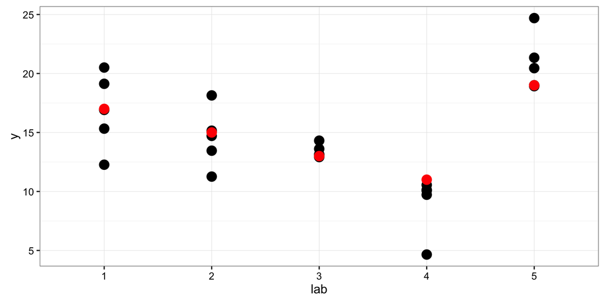

## Example 7.9, Gibbs sampler

```r
## J = (J_1, ..., J_I), ybar = (ybar_1, ..., ybar_I)
gibbsstep <- function(mu, alpha, ybar, J,
                      sigmaeps = 2, sigmaalph = 4) {
 p <- length(alpha)
 n <- sum(J)
 ymean = sum(J * ybar) / n
 V <- 1 / (J / sigmaeps^2 + 1 / sigmaalph^2)
 mu <- rnorm(1, ymean - sum(J * alpha) / n, sigmaeps / sqrt(n))
 alpha <- rnorm(p, J * V * (ybar - mu) / sigmaeps^2, sqrt(V))
 list(mu = mu, alpha = alpha)
}
```

## Example 7.9, Gibbs sampler

```r
gibbs <- function(mu0, alpha0, data, t = 1000, ...) {
  mu <- numeric(t)
  alpha <- matrix(0, length(alpha0), t)
  mu[1] <- mu0
  alpha[, 1] <- alpha0
  J <- table(data$lab)
  ybar <- tapply(data$y, data$lab, mean)
  for(i in 2:t) {
    tmp <- gibbsstep(mu[i - 1], alpha[, i - 1], ybar, J, ...)
    mu[i] <- tmp$mu
    alpha[, i] <- tmp$alpha
  }
  list(mu = mu, alpha = alpha)
}
```

## Example 7.9, Gibbs sampler

```r
tmp <- gibbs(0, rep(0, 5), x, t = 40)
```

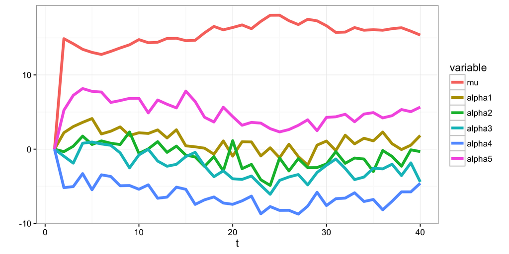

## Example 7.9, Gibbs sampler

```r
tmp <- gibbs(0, rep(0, 5), x, t = 400)
```

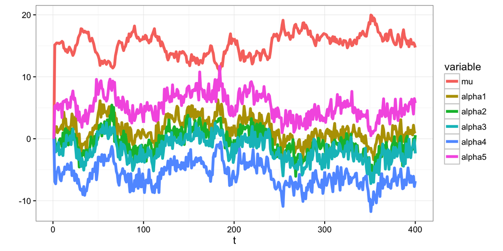

## Example 7.9, Gibbs sampler

```r
tmp <- gibbs(0, rep(0, 5), x, t = 100, sigmaalph = 8)
```

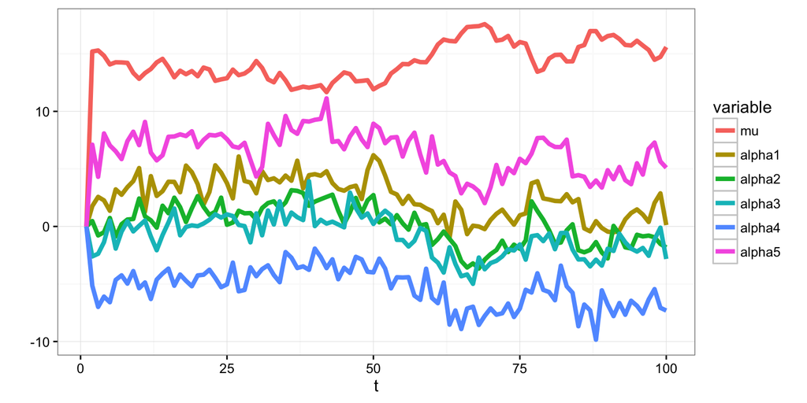

## Example 7.9, Gibbs sampler

```r
tmp <- gibbs(0, rep(0, 5), x, t = 1000, sigmaalph = 8)
```

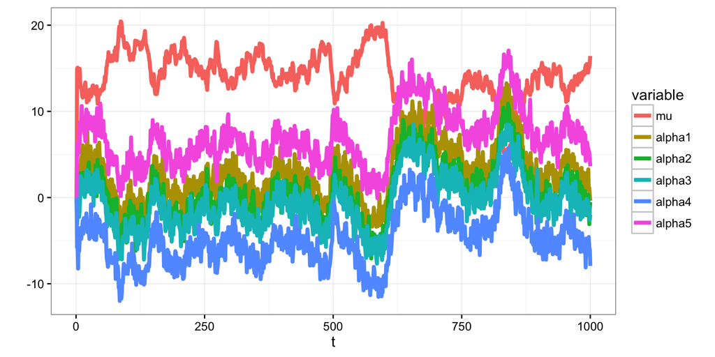

## Example 7.9, Gibbs sampler

```r
tmp <- gibbs(0, rep(0, 5), x, t = 1000, sigmaalph = 4)
```

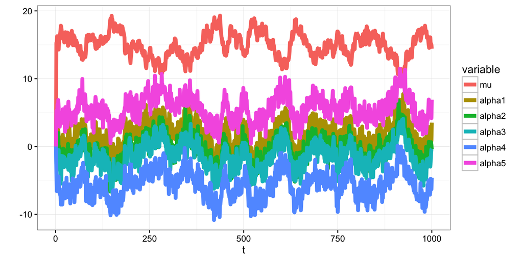

## Posterior distribution for \(\mu + \alpha_1\)

Purple line is posterior mean. Black points are mean and confidence interval.

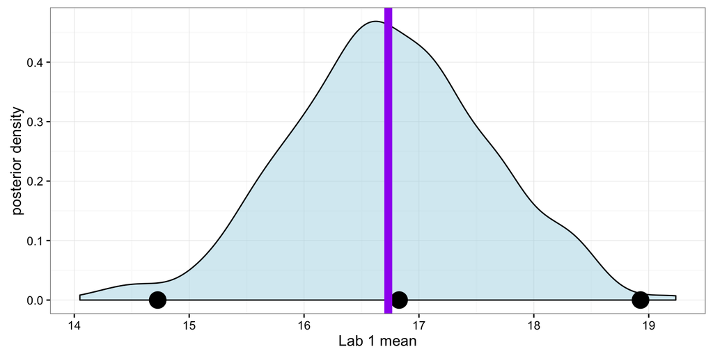

## Marginal posteriors for \(\mu + \alpha_i\)

Red point is true mean. Errorbar is standard confidence interval.

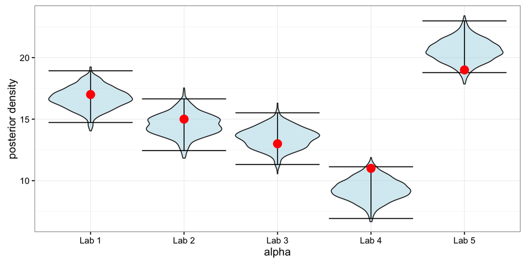

## Marginal posteriors, informative prior

```r
tmp <- gibbs(0, rep(0, 5), x, t = 1000, sigmaalph = 1)
```

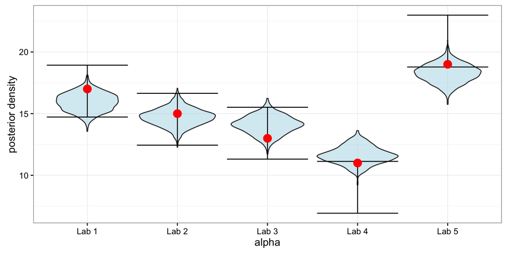

## Why the Gibbs sampler works

Suppose that \((\mu, \alpha_1, \ldots, \alpha_I) \sim h(\cdot \mid y)\) and let \(\mu'\) be the update by the Gibbs sampler of \(\mu'\) given \(\alpha_1, \ldots, \alpha_I, y\).

Then the density of \(\mu', \alpha_1, \ldots, \alpha_I \mid y\) is found as

\[ \begin{aligned} & \int h(\mu, \alpha_1, \ldots, \alpha_I \mid y) h(\mu' \mid \alpha_1, \ldots, \alpha_I, y) \ d\mu = \\ & \ \ \ \ \ \ \ \ \ \ \ \ = \frac{h(\mu', \alpha_1, \ldots, \alpha_I \mid y)}{\int h(\mu', \alpha_1, \ldots, \alpha_I \mid y) \ d\mu'} \int h(\mu, \alpha_1, \ldots, \alpha_I \mid y) \ d\mu \\ & \ \ \ \ \ \ \ \ \ \ \ \ = h(\mu', \alpha_1, \ldots, \alpha_I \mid y) \end{aligned} \]

Thus, the distribution of \(\mu', \alpha_1, \ldots, \alpha_I \mid y\) is again the posterior.

## The Gibbs sampler is a Markov Chain

The Gibbs sampler is clearly a Markov chain, as it is given by a stochastic update formula\(^{(1)}\).

If the Gibbs sampler is initialized by a sample from the posterior all subsequent samples are from the posterior.

The posterior is an *invariant distribution* of the Gibbs sampler as a Markov Chain.

**But how can we get the chain started in the posterior?**

\({}^{(1)}\) Technical note: One typically counts a complete cycle of updates of all parameters as one step in the Markov chain. Otherwise it won't be time homogeneous.

## The Gibbs sampler is a Markov Chain

We can't start the Gibbs sampler in the posterior, but we can start it somewhere and hope that it will converge.

The general theory of Markov Chains gives that if the chain is *irreducible and aperiodic* the distribution of the Gibbs sampler will converge toward the posterior from (almost) all starting values.

It is non-trivial to verify these technical conditions, but they hold for many concrete examples.

The practical consequence of *not* starting the Gibbs sampler in the posterior is that we discard an initial fraction of the samples called the *burn-in period*.

## Burn in

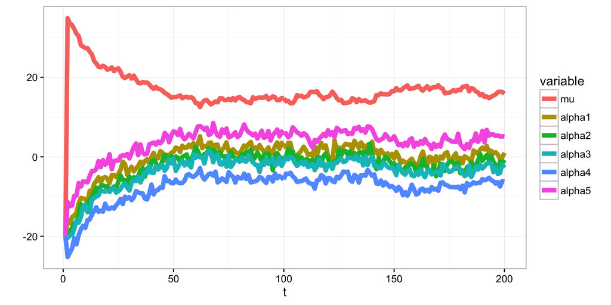

## Ergodic theory

The ergodic theory for Markov Chains implies that integrals w.r.t. the posterior can be approximated by averages.

For instance, \[\int \mu h(\mu, \alpha_1, \ldots, \alpha_I \mid y) \ d\mu \simeq \frac{1}{n} \sum_{i=1}^n \mu^{(i)},\] where \(\mu^{(i)}\) denotes the \(i\)th sample from the Gibbs sampler.

Under further technical conditions on the Markov chain, a CLT applies, but since the samples are dependent, there is no easy formula for the asymptotic variance.

## Ergodic average for \(\mu\)

```r
tmp <- gibbs(15, rep(0, 5), x, t = 1000, sigmaalph = 4)
```

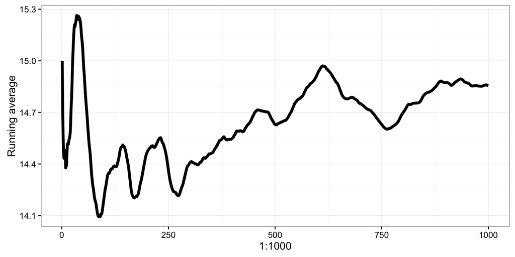

## Autocorrelation, \(\mu\)

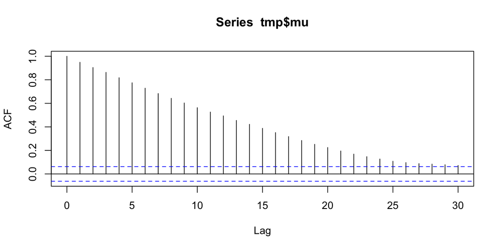

```r
acf(tmp$mu)
```

## Autocorrelations, \(\alpha_1, \alpha_2\)

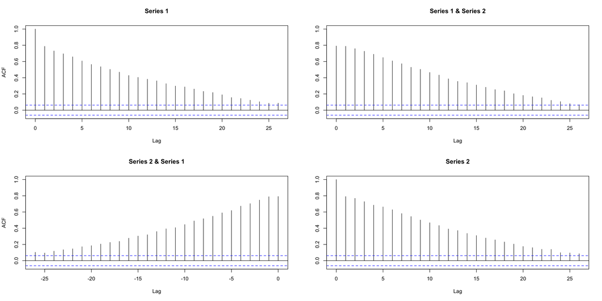

```r
acf(t(tmp$alpha[1:2, ]))
```

## Autocorrelations, \(\mu, \alpha_1\)

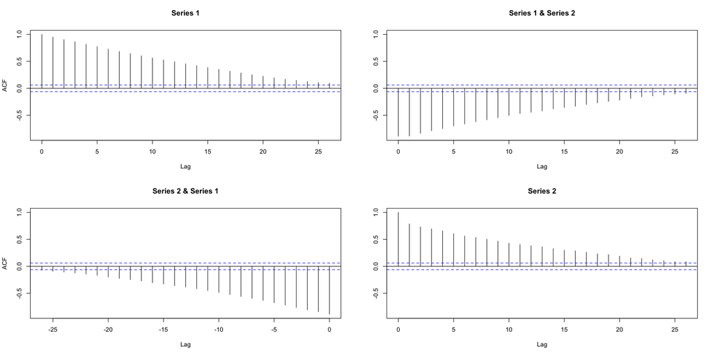

```r
acf(cbind(tmp$mu, tmp$alpha[1, ]))
```

## Autocorrelations

The auto- and cross autocorrelations are shown above for various combinations of the parameters.

There is a slow decay illustrating that the Gibbs sampler produces highly dependent samples. It is sometimes said that the Markov chain is *slowly mixing*. Everything is relative, and this is, for instance, in comparison with i.i.d. samples.

You should note that two \(\alpha\)-chains have positive cross-correlation, while the \(\mu\)- and \(\alpha\)-chains have negative cross-correlation. This is related to the lack of identifiability of the parameters.

## More general methods / considerations

- The Gibbs sampler is one example. The Metropolis-Hastings algorithm is a general Markov Chain construction for sampling (approximately) from any distribution.
- It can be non-trivial in practice to determine if an algorithm has converged.
- Visualizations of samples paths etc. are crucial when dealing with MCMC.
- It is a good idea to run several chains from different initial values.
- MCMC can be used for non-Bayesian computations. Whenever we need samples from a distribution known up to the normalization constant, MCMC is a possible solution.